# ps 4 template

## preliminaries

```r
#clear workspace
rm(list=ls())
#loas data
data = read.csv("MetabolicRate.csv")

# build variable
mRate = log(data$Mrate)
instar = data$Instar
bodySize = log(data$BodySize)
```

# Question 1

## Step 1

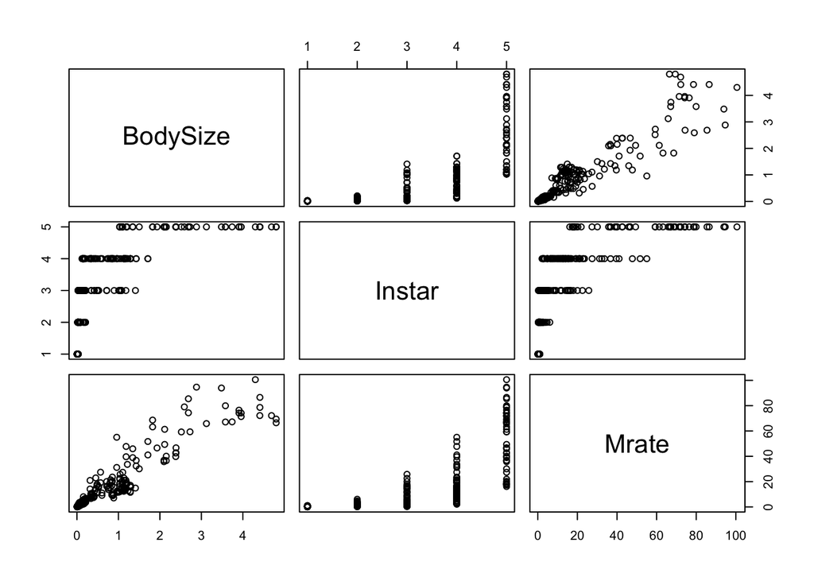

```r
pairs(data)
```

They all appear to be a positively correlated as seen by the scatter plot as pairs() gives us the correlation between variables. We see that the points of each scatter plot appears to be increasing hence the positive correlation between variables. This raises the concerns because we are constructing our likelihood with bodysize and instar as weights which we assume are independent, but according to this they appear positively correlated therefore making it harder to identify the individual contribution of each.

## Step 2

```r
# Build grid
stepBeta0Grid = 0.25
stepBeta1Grid = 0.1
stepBeta2Grid = 0.1
stepSigmaGrid = 0.1

beta0Grid = seq(-5, 5, by = stepBeta0Grid)
beta1Grid = seq(-2, 2, by = stepBeta1Grid)
beta2Grid = seq(-2, 2, by = stepBeta2Grid)
sigmaGrid = seq(0.1, 3, by = stepSigmaGrid)

nBeta0Grid = length(beta0Grid)
nBeta1Grid = length(beta1Grid)
nBeta2Grid = length(beta2Grid)
nSigmaGrid = length(sigmaGrid)

# Uninformed Priors
computePrior <- function() {
  prior = array(rep(1, nBeta0Grid * nBeta1Grid * nBeta2Grid * nSigmaGrid),
                dim = c(nBeta0Grid, nBeta1Grid, nBeta2Grid, nSigmaGrid))
  for (nB0 in 1:nBeta0Grid) {
    for (nB1 in 1:nBeta1Grid) {
      for (nB2 in 1:nBeta2Grid) {
        for (nSig in 1:nSigmaGrid) {
          prior[nB0, nB1, nB2, nSig] = 1 / (nSig ^ 2)
        }
      }
    }
  }
  return(prior)
}

# Compute Likelihood
# y = mRate, x1 = bodySize, x2 = instar
computeLikelihood <- function(y, x1, x2, b0, b1, b2, noise) {
  logLike = sum(log(dnorm(y - (b0 + b1 * x1 + b2 * x2), mean=0, noise)))
  like = exp(logLike)
  return(like)
}

# Compute Posterior
computeJointPost <- function(y, x1, x2, priorM) {
  postM = array(1, dim = c(nBeta0Grid, nBeta1Grid, nBeta2Grid, nSigmaGrid))
  for (nB0 in 1:nBeta0Grid) {
    B0 = beta0Grid[nB0]
    for (nB1 in 1:nBeta1Grid) {
      B1 = beta1Grid[nB1]
      for (nB2 in 1:nBeta2Grid) {
        B2 = beta2Grid[nB2]
        for (nSig in 1:nSigmaGrid) {
          sig = sigmaGrid[nSig]
          prior = priorM[nB0, nB1, nB2, nSig]
          likelihood = computeLikelihood(y, x1, x2, B0, B1, B2, sig)
          posterior = likelihood * prior
          postM[nB0, nB1, nB2, nSig] = posterior
        }
      }
    }
  }
  # normalize
  postM = postM / (sum(postM) * stepBeta0Grid * stepBeta1Grid * stepBeta2Grid * stepSigmaGrid)
  return(postM)
}

#Compute Joint Posterior
priorM = computePrior()
postM = computeJointPost(mRate, bodySize, instar, priorM)
```

### Marginal Posterior Plots

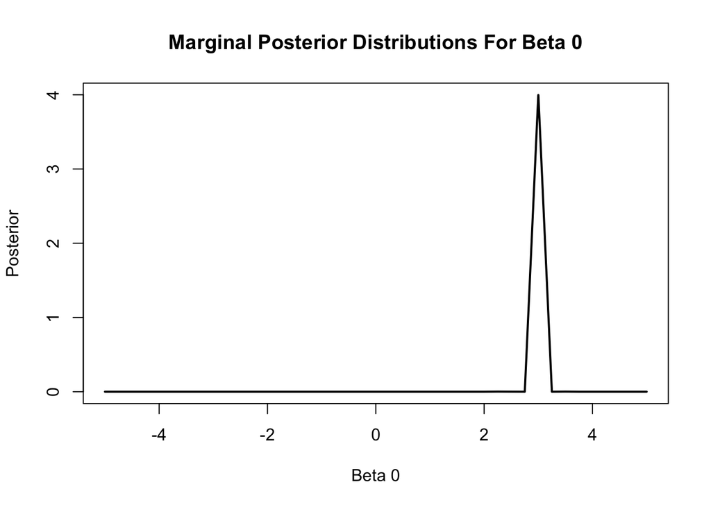

```r
# Posterior Beta 0|data
mPostBeta0 = apply(postM, c(1), sum)
mPostBeta0 = mPostBeta0 /  (sum(mPostBeta0) * stepBeta0Grid)
plot(beta0Grid, mPostBeta0, main = "Marginal Posterior Distributions For Beta 0",
     type="l", lwd=2, xlab="Beta 0", ylab="Posterior")
```

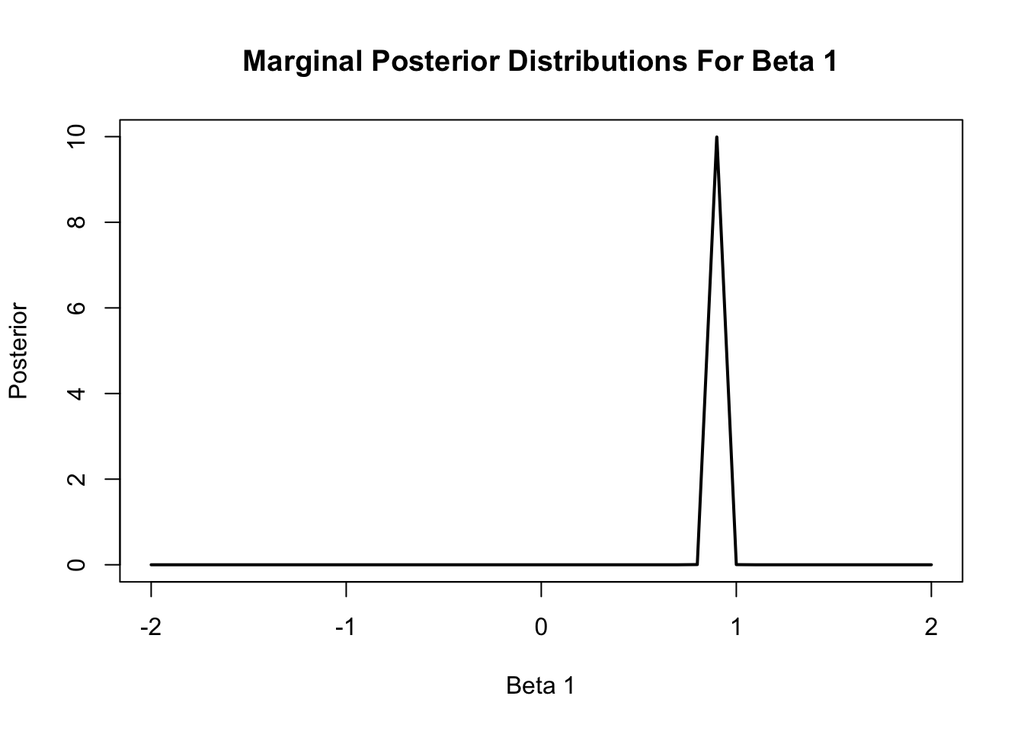

```r
# Posterior Beta 1|data
mPostBeta1 = apply(postM, c(2), sum)
mPostBeta1 = mPostBeta1 /  (sum(mPostBeta1) * stepBeta1Grid)
plot(beta1Grid, mPostBeta1, main = "Marginal Posterior Distributions For Beta 1",
     type="l", lwd=2, xlab="Beta 1", ylab="Posterior")
```

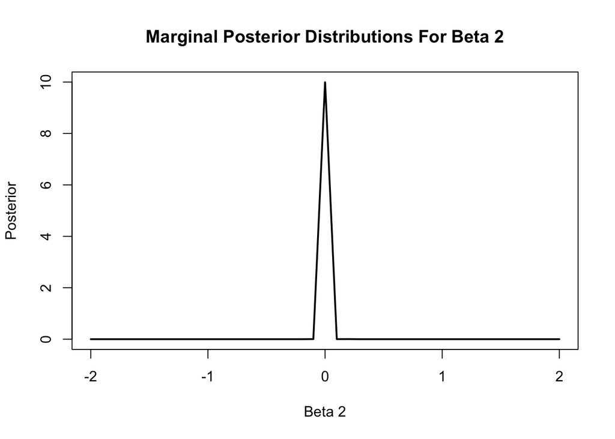

```r
# Posterior Beta 2|data
mPostBeta2 = apply(postM, c(3), sum)
mPostBeta2 = mPostBeta2 /  (sum(mPostBeta2) * stepBeta2Grid)
plot(beta2Grid, mPostBeta2, main = "Marginal Posterior Distributions For Beta 2",
     type="l", lwd=2, xlab="Beta 2", ylab="Posterior")
```

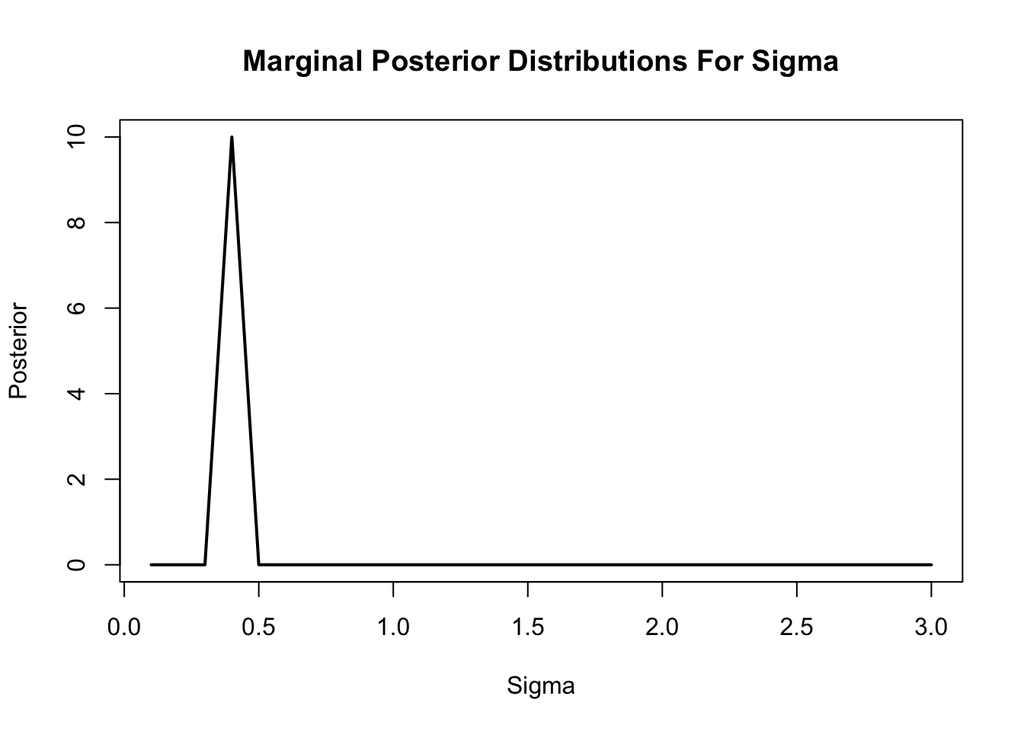

```r
# Posterior Sigma|data
mPostSigma = apply(postM, c(4), sum)
mPostSigma = mPostSigma /  (sum(mPostSigma) * stepSigmaGrid)
plot(sigmaGrid, mPostSigma, main = "Marginal Posterior Distributions For Sigma",
     type="l", lwd=2, xlab="Sigma", ylab="Posterior")
```

### Marginal Posterior Plots For Second Part

```r
stepBeta0Grid = 0.05
stepBeta1Grid = 0.01
stepBeta2Grid = 0.01
stepSigmaGrid = 0.1

beta0Grid = seq(2, 4, by = stepBeta0Grid)
beta1Grid = seq(0.5, 1, by = stepBeta1Grid)
beta2Grid = seq(-0.25, 0.25, by = stepBeta2Grid)
sigmaGrid = seq(0.1, 1, by = stepSigmaGrid)

nBeta0Grid = length(beta0Grid)
nBeta1Grid = length(beta1Grid)
nBeta2Grid = length(beta2Grid)
nSigmaGrid = length(sigmaGrid)

#Compute Joint Posterior
priorM = computePrior()
postM = computeJointPost(mRate, bodySize, instar, priorM)
```

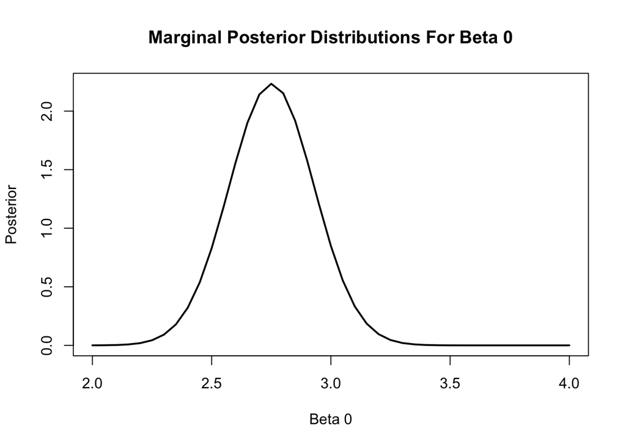

```r
# Posterior Beta 0|data
mPostBeta0 = apply(postM, c(1), sum)
mPostBeta0 = mPostBeta0 /  (sum(mPostBeta0) * stepBeta0Grid)
plot(beta0Grid, mPostBeta0, main = "Marginal Posterior Distributions For Beta 0",
     type="l", lwd=2, xlab="Beta 0", ylab="Posterior")
```

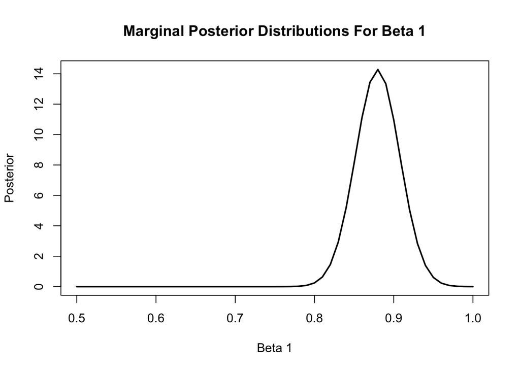

```r
# Posterior Beta 1|data
mPostBeta1 = apply(postM, c(2), sum)
mPostBeta1 = mPostBeta1 /  (sum(mPostBeta1) * stepBeta1Grid)
plot(beta1Grid, mPostBeta1, main = "Marginal Posterior Distributions For Beta 1",
     type="l", lwd=2, xlab="Beta 1", ylab="Posterior")
```

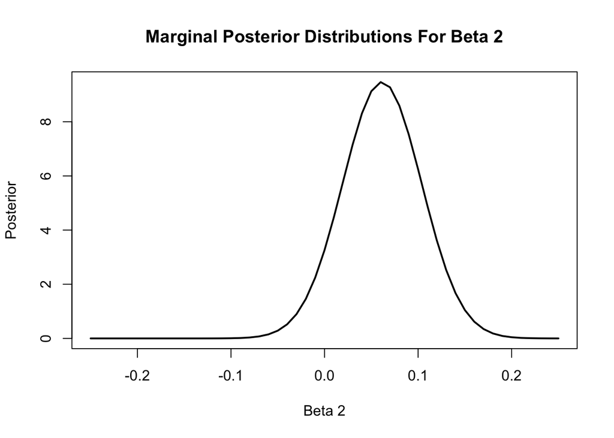

```r
# Posterior Beta 2|data
mPostBeta2 = apply(postM, c(3), sum)
mPostBeta2 = mPostBeta2 /  (sum(mPostBeta2) * stepBeta2Grid)
plot(beta2Grid, mPostBeta2, main = "Marginal Posterior Distributions For Beta 2",
     type="l", lwd=2, xlab="Beta 2", ylab="Posterior")
```

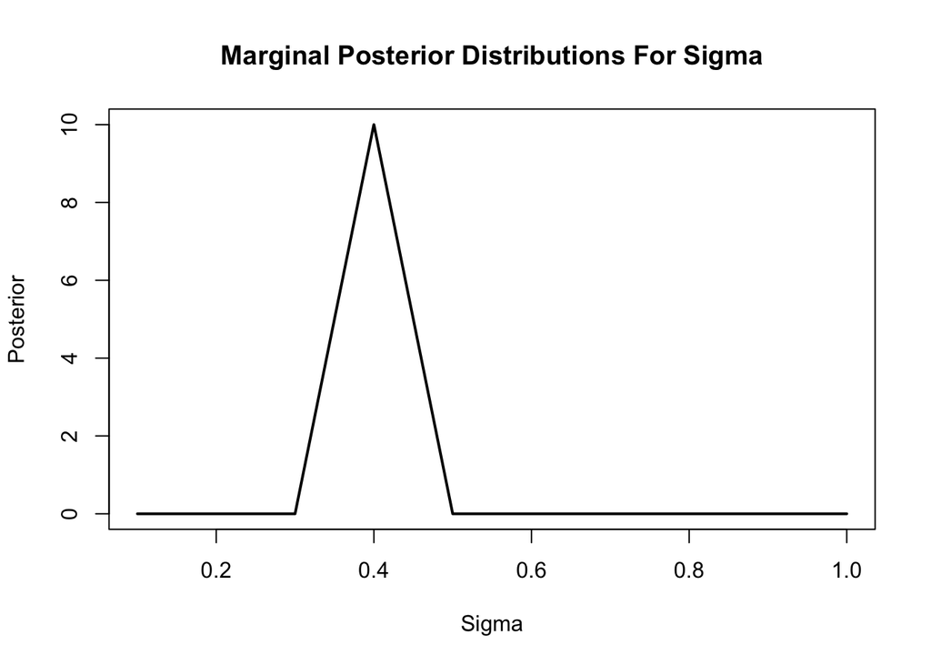

```r
# Posterior Sigma|data
mPostSigma = apply(postM, c(4), sum)
mPostSigma = mPostSigma /  (sum(mPostSigma) * stepSigmaGrid)
plot(sigmaGrid, mPostSigma, main = "Marginal Posterior Distributions For Sigma",
     type="l", lwd=2, xlab="Sigma", ylab="Posterior")
```

```r
## Enter code here ##
stepBeta0Grid = 0.05
stepBeta1Grid = 0.01
stepBeta2Grid = 0.01
stepSigmaGrid = 0.005

beta0Grid = seq(2, 3.5, by = stepBeta0Grid)
beta1Grid = seq(0.75, 1, by = stepBeta1Grid)
beta2Grid = seq(-0.1, 0.25, by = stepBeta2Grid)
sigmaGrid = seq(0.3, 0.5, by = stepSigmaGrid)

nBeta0Grid = length(beta0Grid)
nBeta1Grid = length(beta1Grid)
nBeta2Grid = length(beta2Grid)
nSigmaGrid = length(sigmaGrid)

#Compute Joint Posterior
priorM = computePrior()
postM = computeJointPost(mRate, bodySize, instar, priorM)
```

### Marginal Posterior Plots For Gridsize I picked

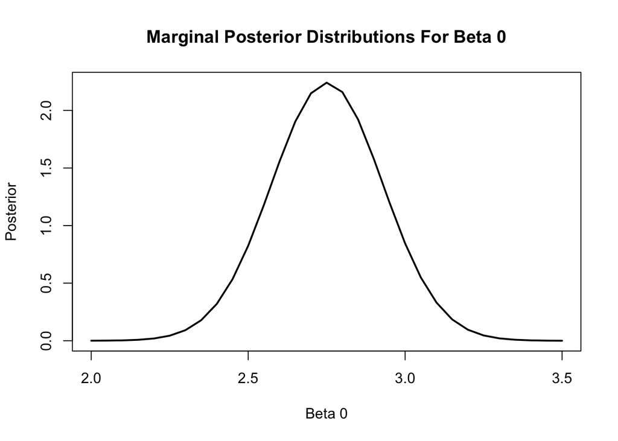

```r
# Posterior Beta 0|data
mPostBeta0 = apply(postM, c(1), sum)
mPostBeta0 = mPostBeta0 /  (sum(mPostBeta0) * stepBeta0Grid)
plot(beta0Grid, mPostBeta0, main = "Marginal Posterior Distributions For Beta 0",
     type="l", lwd=2, xlab="Beta 0", ylab="Posterior")
```

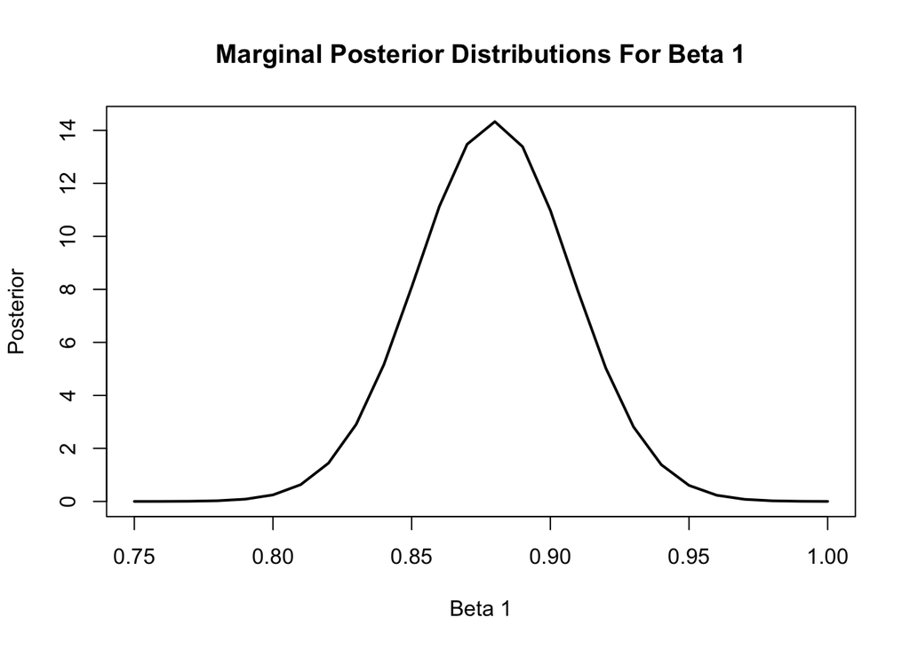

```r
# Posterior Beta 1|data
mPostBeta1 = apply(postM, c(2), sum)
mPostBeta1 = mPostBeta1 /  (sum(mPostBeta1) * stepBeta1Grid)
plot(beta1Grid, mPostBeta1, main = "Marginal Posterior Distributions For Beta 1",
     type="l", lwd=2, xlab="Beta 1", ylab="Posterior")
```

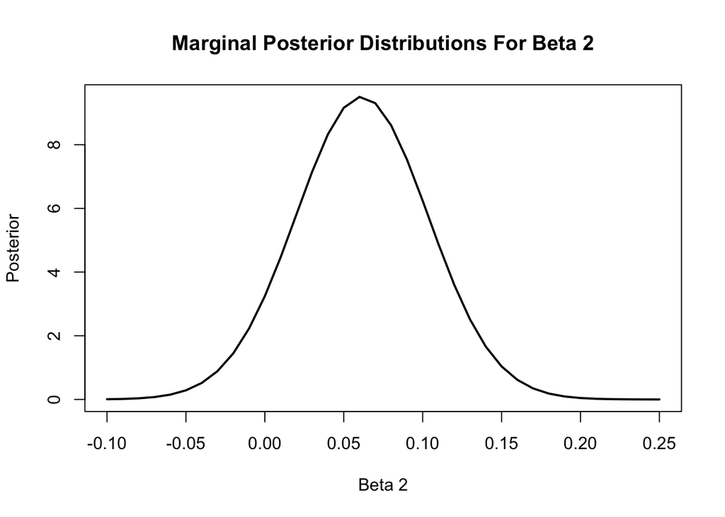

```r
# Posterior Beta 2|data
mPostBeta2 = apply(postM, c(3), sum)
mPostBeta2 = mPostBeta2 /  (sum(mPostBeta2) * stepBeta2Grid)
plot(beta2Grid, mPostBeta2, main = "Marginal Posterior Distributions For Beta 2",
     type="l", lwd=2, xlab="Beta 2", ylab="Posterior")
```

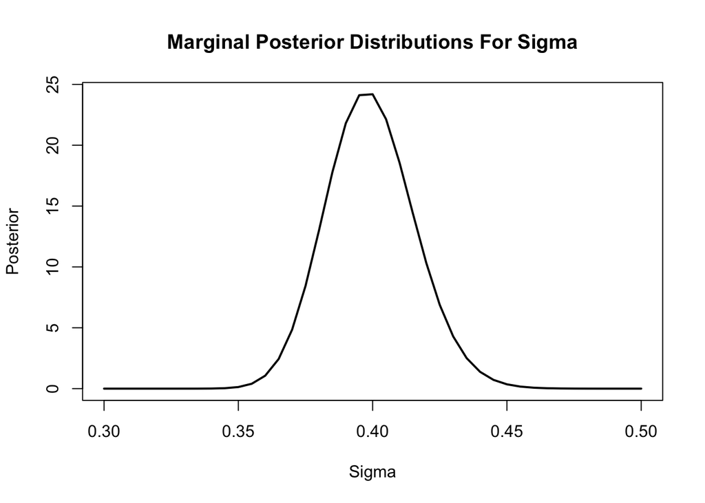

```r
# Posterior Sigma|data
mPostSigma = apply(postM, c(4), sum)
mPostSigma = mPostSigma /  (sum(mPostSigma) * stepSigmaGrid)
plot(sigmaGrid, mPostSigma, main = "Marginal Posterior Distributions For Sigma",
     type="l", lwd=2, xlab="Sigma", ylab="Posterior")
```

Final Grid for step 2 using specualtion: stepBeta0Grid = 0.05 stepBeta1Grid = 0.01 stepBeta2Grid = 0.01 stepSigmaGrid = 0.005 Here having 0.001 gives a realy nice smooth graph, but takes too long to compute.

beta0Grid = seq(2, 3.5, by = stepBeta0Grid) beta1Grid = seq(0.75, 1, by = stepBeta1Grid) beta2Grid = seq(-0.1, 0.25, by = stepBeta2Grid) sigmaGrid = seq(0.3, 0.5, by = stepSigmaGrid)

## Step 3

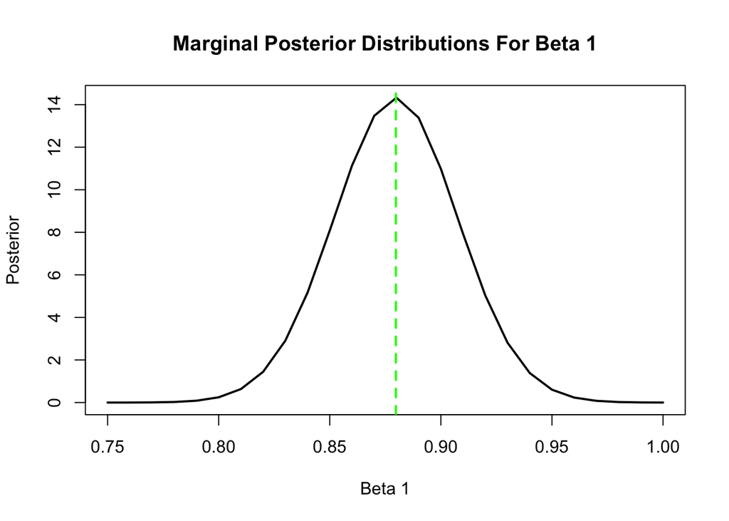

```r
# Marginal Posterior Beta 1|data
mean_mPostBeta1 = sum(beta1Grid * mPostBeta1) * stepBeta1Grid
plot(beta1Grid, mPostBeta1, main = "Marginal Posterior Distributions For Beta 1",
     type="l", lwd=2, xlab="Beta 1", ylab="Posterior")
abline(v= mean_mPostBeta1, lwd=2, lty=2, col="green")
```

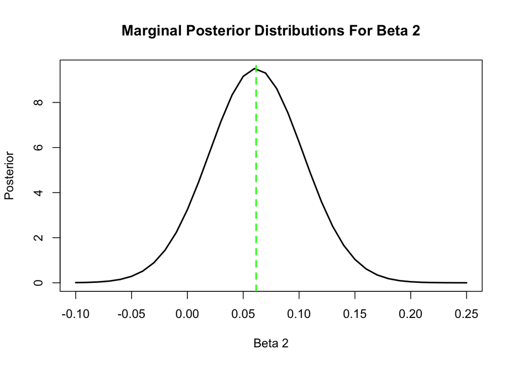

```r
# Marginal Posterior Beta 1|data
mean_mPostBeta2 = sum(beta2Grid * mPostBeta2) * stepBeta2Grid
plot(beta2Grid, mPostBeta2, main = "Marginal Posterior Distributions For Beta 2",
     type="l", lwd=2, xlab="Beta 2", ylab="Posterior")
abline(v= mean_mPostBeta2, lwd=2, lty=2, col="green")
```

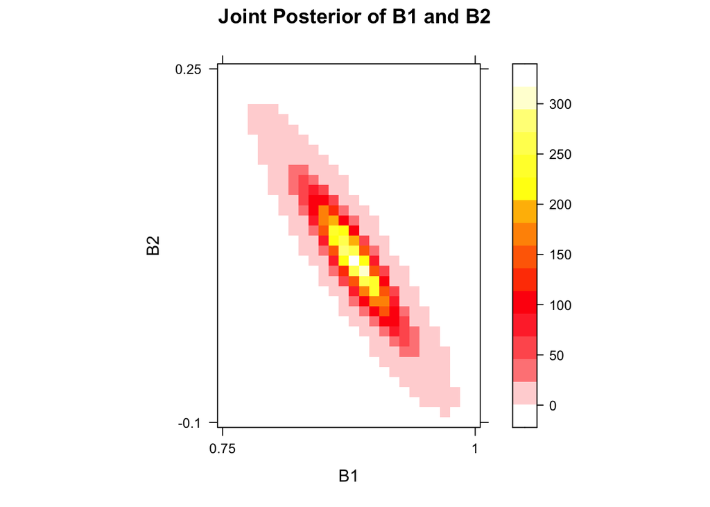

```r
# joint posterior (i.e., for 𝑃(𝛽 , 𝛽 |𝑑𝑎𝑡𝑎)).
mPostBeta2_3 = apply(postM, c(2, 3), sum)
mPostBeta2_3 = mPostBeta2_3 / (sum(mPostBeta2_3) * stepBeta1Grid * stepBeta2Grid)
library(lattice)
new.palette=colorRampPalette(c("white","red","yellow","white"),space="rgb")
levelplot(main="Joint Posterior of B1 and B2",mPostBeta2_3, col.regions=new.palette(20),
  xlab = "B1", ylab = "B2",
  scales=list(x=list(at=c(1,nBeta1Grid), labels=c(0.75,1)),
                      y=list(at=c(1,nBeta2Grid), labels=c(-0.1,0.25))))
```

## Step 4

It has this shape because as we have seen earlier in our scatter plot, body size and instar were not independent and in fact were positively correlated hence the weights assigned to each should be correlated and mostly potive as well. This is why we see B1 and B2 being correlated. Here, as B1 increases B2 decreases and vise versa as the two are negatively correlated. Their total contribution is the result of their individual impact therefore the more weight one has, the less the other has hence the negative correlation seen between B1 and B2 above to maintain their total contribution.

## Step 5

```r
# probability that both 𝛽1 and 𝛽2 are greater than zero.
prop = 0
for (nB1 in 1:nBeta1Grid) {
  for (nB2 in 1:nBeta2Grid) {
    if(beta1Grid[nB1] > 0 && beta2Grid[nB2] > 0)
      prop = prop + mPostBeta2_3[nB1, nB2]
  }
}
# Normalize
prop = prop / sum(mPostBeta2_3)
cat("probability that both B1 and B2 are greater than zero: ", round(prop, 5))
```

```
## probability that both B1 and B2 are greater than zero:  0.91108
```

# Question 2

## Step 1

I expect this shift to be upwards as B1 and B2 are negatively correlated as seen above and both are mostly positive (over 90%) therefore excluding bodySize will lead the weight for instar to account for bodySize’s imapct, as the two are correlated, leading it to weight more hence more positive as seen in the heat map.

## Step 2

```r
stepBeta0Grid = 0.02
stepBeta1Grid = 0.01
stepSigmaGrid = 0.005

beta0Grid = seq(-3.5, -1.5, by = stepBeta0Grid)
beta1Grid = seq(1.1, 1.5, by = stepBeta1Grid)
sigmaGrid = seq(0.6, 1, by = stepSigmaGrid)

nBeta0Grid = length(beta0Grid)
nBeta1Grid = length(beta1Grid)
nSigmaGrid = length(sigmaGrid)

computeUniPrior <-function() {
  prior = array(1, dim = c(nBeta0Grid, nBeta1Grid, nSigmaGrid))
  for (nB0 in 1:nBeta0Grid) {
    for (nB1 in 1:nBeta1Grid) {
      for (nsig in 1:nSigmaGrid) {
        prior[nB0, nB1, nsig] = 1 / (nsig ^ 2)
      }
    }
  }
  return(prior)
}

computeUniLikelihood <- function(y, x, b0, b1, noise) {
  loglike = sum(log(dnorm(y, (b0 + b1 * x), noise)))
  like = exp(loglike)
  return(like)
}

computeUniJointPost <- function(y, x, priorM) {
  postM = array(1, dim = c(nBeta0Grid, nBeta1Grid, nSigmaGrid))
  for (nB0 in 1:nBeta0Grid) {
    B0 = beta0Grid[nB0]
    for (nB1 in 1:nBeta1Grid) {
      B1 = beta1Grid[nB1]
      for (nsig in 1:nSigmaGrid) {
        sig = sigmaGrid[nsig]
        liklihood = computeUniLikelihood(y, x, B0, B1, sig)
        prior = priorM[nB0, nB1, nsig]
        postM[nB0, nB1, nsig] = liklihood * prior
      }
    }
  }
  postM = postM / (sum(postM) * stepBeta1Grid * stepBeta2Grid * stepSigmaGrid)
}

priorM = computeUniPrior()
postM = computeUniJointPost(mRate, instar, priorM)
```

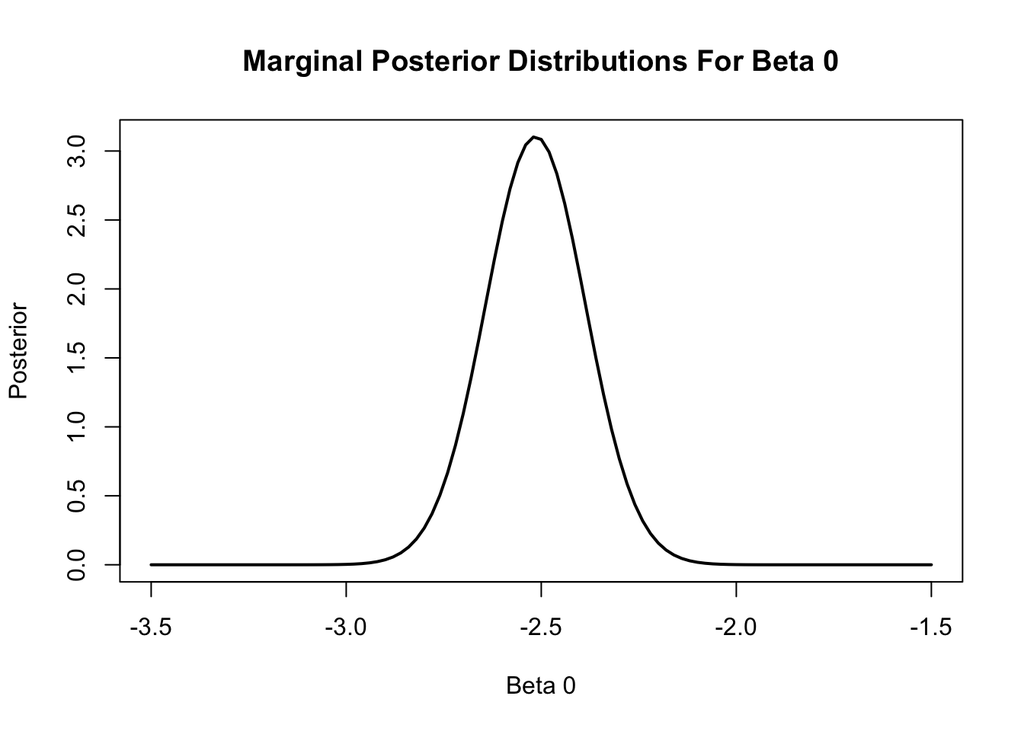

```r
# Posterior Beta 0|data
mPostBeta0 = apply(postM, c(1), sum)
mPostBeta0 = mPostBeta0 /  (sum(mPostBeta0) * stepBeta0Grid)
plot(beta0Grid, mPostBeta0, main = "Marginal Posterior Distributions For Beta 0",
     type="l", lwd=2, xlab="Beta 0", ylab="Posterior")
```

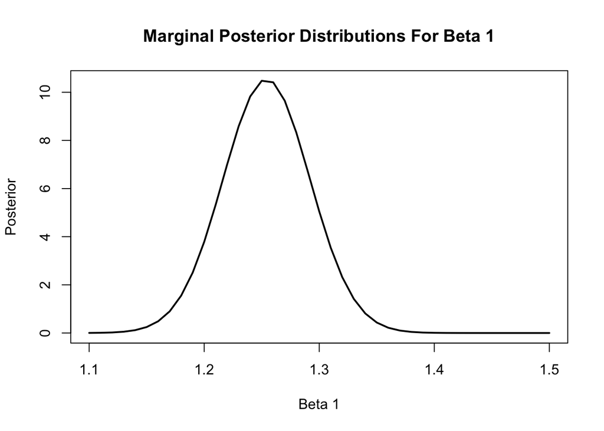

```r
# Posterior Beta 1|data
mPostBeta1 = apply(postM, c(2), sum)
mPostBeta1 = mPostBeta1 /  (sum(mPostBeta1) * stepBeta1Grid)
plot(beta1Grid, mPostBeta1, main = "Marginal Posterior Distributions For Beta 1",
     type="l", lwd=2, xlab="Beta 1", ylab="Posterior")
```

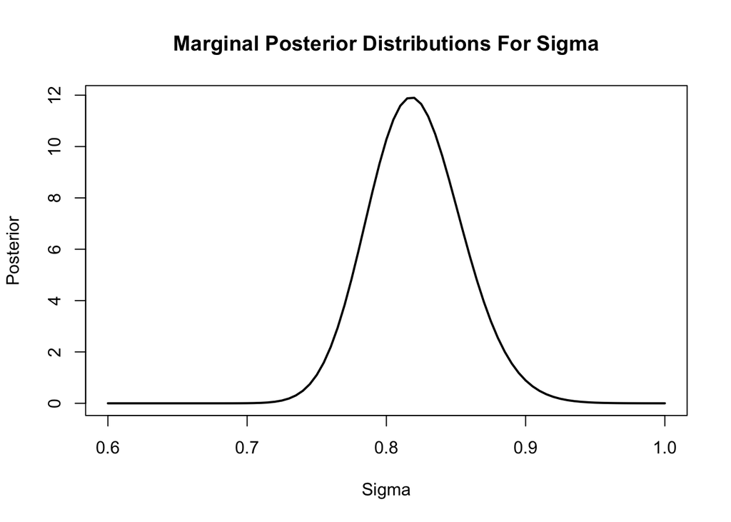

```r
# Posterior Sigma|data
mPostSigma = apply(postM, c(3), sum)
mPostSigma = mPostSigma /  (sum(mPostSigma) * stepSigmaGrid)
plot(sigmaGrid, mPostSigma, main = "Marginal Posterior Distributions For Sigma",
     type="l", lwd=2, xlab="Sigma", ylab="Posterior")
```

## Step 3

```r
mean_mPostBeta1U = sum(mPostBeta1 * beta1Grid) * stepBeta1Grid
cat("mean marginal posteriors for Beta 1 under the univariate: ", mean_mPostBeta1U, "\n")
```

```
## mean marginal posteriors for Beta 1 under the univariate:  1.254126
```

```r
cat("mean marginal posteriors for Beta 1 under the bivariate: ", mean_mPostBeta2 + mean_mPostBeta1)
```

```
## mean marginal posteriors for Beta 1 under the bivariate:  0.9412747
```

Here we have a more positive mean Beta instar as it has to account for the weight of Beta 1 and Beta 2 in the bivariate model by itself. As both beta 1 and beta 2 had a positve impact in the bivariate model, and one of them is being excluded here, then the other accounts for it’s impact and as the two are negatively correlated leading to the upward shift predicted earlier and a more positive mean.

## Step 4

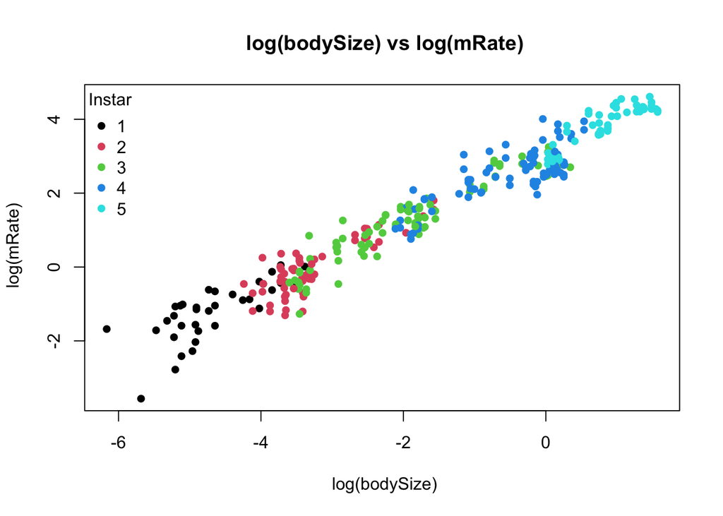

```r
#Everythign else already logged.
plot(main = " log(bodySize) vs log(mRate)", bodySize, mRate,
     col = as.numeric(instar), pch=16, xlab=" log(bodySize)", ylab=" log(mRate)")
legend("topleft", legend=unique(instar), col=1:5, pch = 16, title = "Instar", bty="n")
```

In the plot we see that bodysize linearly increases with the instar stage which makes sense as we saw in our first plot using pairs that the two were positively correlated. Also, we see that as the these parameters increase so does the organism’s mRate meaning that as mRate increases as either of them increases leading to a positive impact. Furthermore, we see some manducta (asides from a couple of outliers which could be due to genetics) in the same stage have different metabolic rates based on bodySize with higher bodysize leading to higher mRates therefore suggesting that bodysize might be a better predictor in our previous uni-variate case.